# Impacts of the request expiry feature has on users’ behaviour

## Introduction

## Introduction

In this project, we are given several datasets from Riipen, an education technology company that helps connecting schools and employers to create project based learning opportunities. They provide a platform that allows employers to apply to work with professors as well as allows professors to apply to work with companies. And in order to reduce users’ frustration caused by waiting long time for responses from others, the company launched a new feature named “request expiry” in November, 2018. This new feature requires users to respond to requests with 14 days, or they will expire.

## Obejctives

Our objective is to discover whether Riipen launch of the new feature had any impact on the users’ behaviours through mainly using the “requests” dataset and comparing volume of requests, request response time, request acceptance rate, and request expiry rate.

## Vloume of requests

## Avgerage Monthly Requests Volume

```
## # A tibble: 4 x 3
## # Groups:   requestable_model [2]
##   requestable_model request_time avg_monthly_requests
##   <chr>             <chr>                       <dbl>
## 1 course            after                        51.2
## 2 course            before                       24.6
## 3 project           after                        68.2
## 4 project           before                      268
```

- Monthly volume of requests for course was more after the new feature launched
- Monthly volume of requests for project became less after the new feature launched
- The request expiry feature might lead to more company applying course but less professor applying to work with project.

## Volume Of Requests(Project)

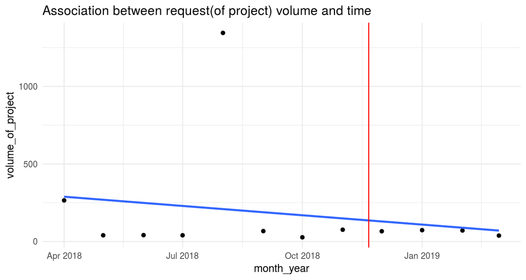

```
##                  Estimate   Std. Error    t value  Pr(>|t|)
## (Intercept) 11804.1177568 18689.631176  0.6315864 0.5418248
## month_year     -0.6534681     1.050566 -0.6220154 0.5478505
```

## Volume Of Requests(Project)

- Create scatterplot to visualize the association between number of requests for project(per month) and time
- Blue line: line of best fit Red line: represent 2018-11-21
- Outliers at Apr 2018(when “request” feature launched) and Aug 2018(database clean up event)
- But request volume tend to stay relitively constant overtime
- Fit in simple linear regression model to find out the relationship between number of requests for project and time
- p-value = 0.547, no evidence against the null hypothesis that there’s no relationship between project request volume and time
- The new feature did not have much impact on valume of requests for peoject
- Limitation: only have datas on a few months

## Volume Of Requests(Course)

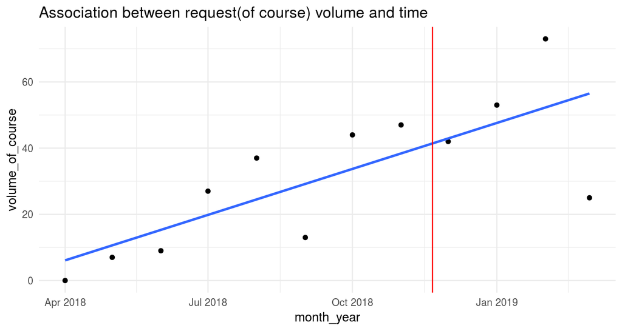

```
##                  Estimate   Std. Error   t value    Pr(>|t|)
## (Intercept) -2653.8015173 721.68733811 -3.677218 0.004265938
## month_year      0.1509419   0.04056688  3.720815 0.003969938
```

## Request Response Time

## Request Response Time

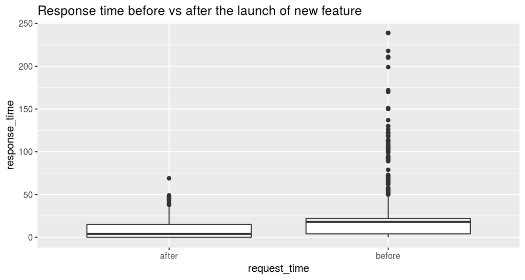

## Request Response Time

- Many response time of 0 day on Aug.30th due to database clearance event, filter out these data first
- Both group have outliers above their upper whiskers. Before group has more outliers and outliers on the tail of the distribution are more extreme.
- Median response time before(18 days) was was longer than median response time after(4 days) the launch of new feature
- IQR before: 18 days, IQR after: 15 days
- Response time shortened after the launch of new feature

## Request Acceptance Rate

## Request Acceptance Rate

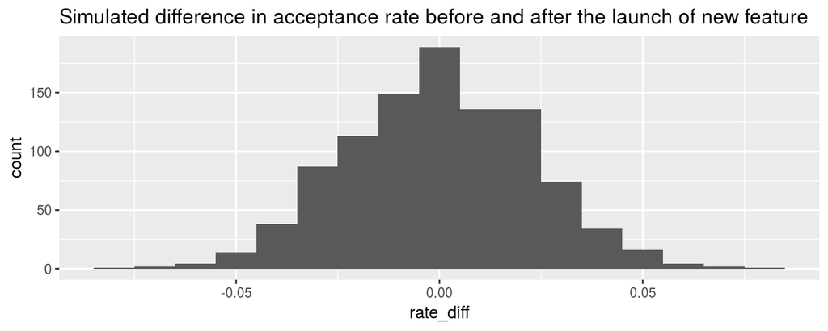

```
## [1] 0.2416468
```

```
## [1] 0
```

- Distribution of test statistics that are simulated under H0
- Centered at 0

## Request Acceptance Rate

- Conduct hypothesis test to see if there is any change in request acceptance rate before and after the new feature launched
- H0: acceptance rate before = acceptance rate after(acceptance rate before - acceptance rate after = 0) H1: acceptance rate before \(\neq\) acceptance rate after(acceptance rate before - acceptance rate after \(\neq\) = 0)
- test statistic = 0.24
- p-value = 0, showing very strong evidence against H0 that acceptance rate before equals acceptance rate after
- Test statistic shows evidence that acceptance rate before was higher than after the “request expiry” feature launched.
- Limitation: might made Type I error(reject H0 when H0 is true)

## Request Expiry Rate

## Boxplot

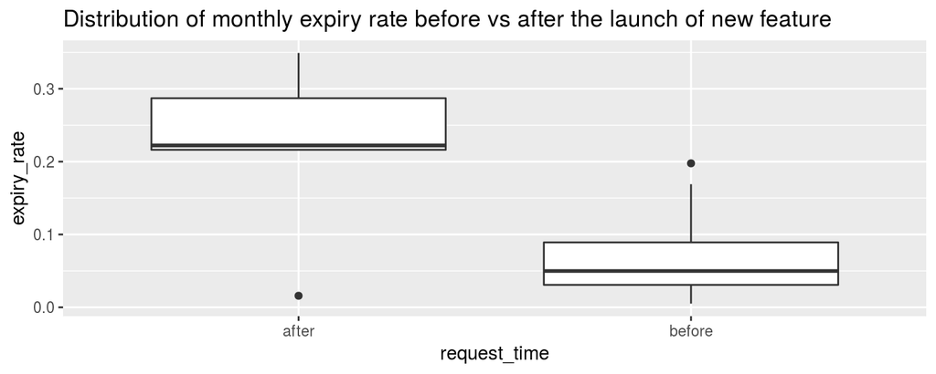

## Request Expiry Rate

- Use boxplot for visualizing and comparing the distribution of expiry rate(of each month) before and after the launcn of “request expiry” feature
- Median expiry rate after is higher than median expiry rate before the launch of new feature
- Only have expiry rate for a few month(not a large sample size), but there is obvious difference between the two distributions
- Generally, expiry rate after is higher than expiry rate before the launch of new feature
- Since the “request expiry” feature was launched after 2018-11-21, the requests created before would not expire until 2018-12-06(14 days after the new feature launched)